# Cox Proportional Hazards Regression

CRP 245 Tutorial

Author

Duke University Clinical Research Training Program

Published

January 22, 2026

# Introduction

**Learning Objectives**

After completing this tutorial, you will be able to:

- **Understand** the purpose and assumptions of Cox Proportional Hazards regression.
- **Estimate** Hazard Ratios for treatment effects and patient characteristics.
- **Interpret** hazard ratios for both categorical and continuous predictors.
- **Calculate** hazard ratios for clinically meaningful intervals (e.g., 5-year age change).
- **Visualize** survival curves with Kaplan-Meier plots stratified by predictors.
- **Distinguish** between statistical significance and clinical importance.

## 0.1 Clinical Context

When treating patients with serious chronic conditions, a critical question is: **“How much does this treatment reduce the risk of a bad outcome?”** Cox Proportional Hazards regression provides a rigorous method to answer this question while accounting for the fact that not all patients experience the outcome during follow-up.

**Why Cox Regression?**

Unlike simple comparison of event rates, Cox regression:

1. **Accounts for censoring** — patients who don’t experience the event by study end still contribute information.
2. **Adjusts for covariates** — we can separate treatment effects from patient characteristics.
3. **Provides Hazard Ratios** — an intuitive measure of relative risk over time.

## 0.2 Study Overview: The CGD Trial

This tutorial uses data from a landmark randomized, double-blind, placebo-controlled clinical trial investigating recombinant gamma interferon (IFN-γ) for preventing serious infections in chronic granulomatous disease (CGD).

**About CGD:**

- CGD is a rare inherited immunodeficiency (1 in 200,000 individuals)
- Characterized by recurrent, life-threatening bacterial and fungal infections
- Primarily affects males (X-linked inheritance pattern)
- Often diagnosed in childhood

**Study Design:**

- Patients randomized 1:1 to gamma interferon vs. placebo
- Primary endpoint: Time to first serious infection

## 0.3 Data Dictionary

CGD Trial Key Variables

[output not shown]

# 1 Setup and Data Loading

## 1.1 Loading Required Packages

We begin by loading the specialized R packages required for survival analysis. Each package serves a specific purpose.

```r
# survival: Core package for Cox regression and Kaplan-Meier estimation
# Key functions: Surv(), coxph(), survfit()
if (!requireNamespace("survival", quietly = TRUE)) install.packages("survival")
library(survival)

# survminer: Publication-quality survival plots
# Key function: ggsurvplot()
if (!requireNamespace("survminer", quietly = TRUE)) install.packages("survminer")
library(survminer)
```

## 1.2 Loading the Data

We load the CGD trial dataset and examine the study population.

```r
# Load the trial data
load(url("https://www.duke.edu/~sgrambow/crp241data/cgd.RData"))

# Examine data structure
str(cgd)
```

```
'data.frame':   128 obs. of  10 variables:
 $ id      : int  1 2 3 4 5 6 7 8 9 10 ...
 $ treat   : num  1 0 1 1 0 1 0 1 0 1 ...
 $ sex     : num  0 1 1 1 1 0 1 1 1 1 ...
 $ age     : int  12 15 19 12 17 44 22 7 27 5 ...
 $ height  : num  147 159 171 142 162 ...
 $ weight  : num  62 47.5 72.7 34 52.7 45 59.7 17.4 82.8 19.5 ...
 $ inherit : num  0 0 1 1 1 0 1 1 0 1 ...
 $ propylac: int  0 1 1 1 1 0 1 1 1 1 ...
 $ tstop   : int  219 8 382 388 246 364 292 363 294 371 ...
 $ status  : int  1 1 0 0 1 0 1 0 1 0 ...
```

```r
# Summary statistics
summary(cgd)
```

```
       id             treat             sex              age
 Min.   :  1.00   Min.   :0.0000   Min.   :0.0000   Min.   : 1.00
 1st Qu.: 32.75   1st Qu.:0.0000   1st Qu.:1.0000   1st Qu.: 7.00
 Median : 64.50   Median :0.0000   Median :1.0000   Median :12.00
 Mean   : 64.81   Mean   :0.4922   Mean   :0.8125   Mean   :14.64
 3rd Qu.: 96.25   3rd Qu.:1.0000   3rd Qu.:1.0000   3rd Qu.:22.00
 Max.   :135.00   Max.   :1.0000   Max.   :1.0000   Max.   :44.00
     height          weight          inherit          propylac
 Min.   : 76.3   Min.   : 10.40   Min.   :0.0000   Min.   :0.0000
 1st Qu.:116.5   1st Qu.: 20.68   1st Qu.:0.0000   1st Qu.:1.0000
 Median :140.8   Median : 34.85   Median :1.0000   Median :1.0000
 Mean   :140.1   Mean   : 40.56   Mean   :0.6719   Mean   :0.8672
 3rd Qu.:169.7   3rd Qu.: 59.17   3rd Qu.:1.0000   3rd Qu.:1.0000
 Max.   :189.0   Max.   :101.50   Max.   :1.0000   Max.   :1.0000
     tstop           status
 Min.   :  4.0   Min.   :0.0000
 1st Qu.:197.0   1st Qu.:0.0000
 Median :269.0   Median :0.0000
 Mean   :241.1   Mean   :0.3438
 3rd Qu.:304.5   3rd Qu.:1.0000
 Max.   :388.0   Max.   :1.0000
```

**Statistical Interpretation**

**Clinical Context**

# 2 Exploratory Visualization

Before formal regression modeling, we visualize survival differences between treatment arms using Kaplan-Meier curves.

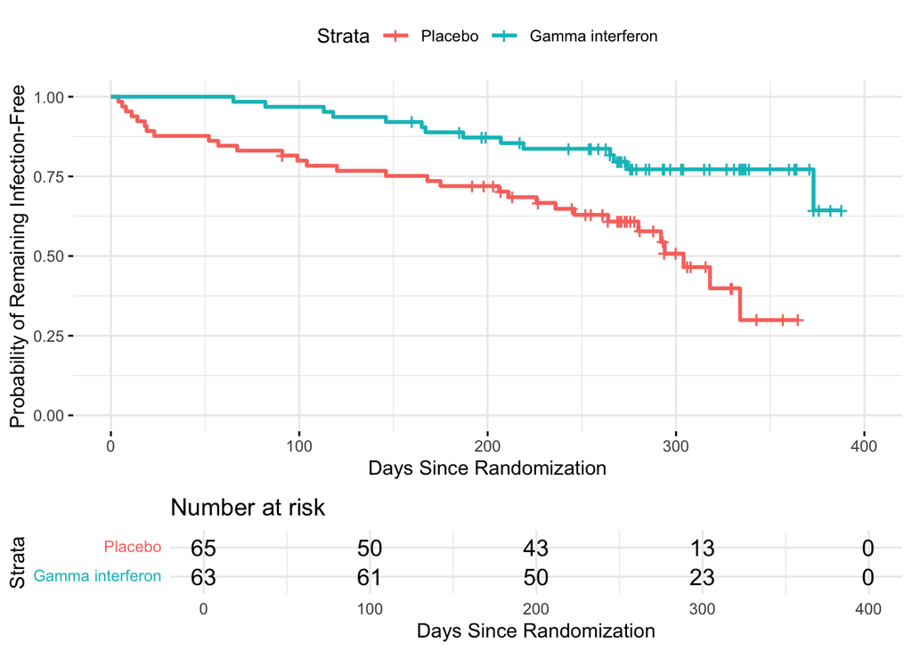

Figure 1: Kaplan-Meier Curves by Treatment Group

```r
# Create Kaplan-Meier survival estimates stratified by treatment
fit.km <- survfit(Surv(tstop, status) ~ treat, data=cgd)

# Generate publication-quality plot with risk table
ggsurvplot(fit.km, data=cgd,
           ggtheme = theme_minimal(),
           legend.labs = c("Placebo","Gamma interferon"),
           risk.table = TRUE,
           xlab = "Days Since Randomization",
           ylab = "Probability of Remaining Infection-Free")
```

**Visual Finding**

The curves separate early and maintain separation throughout follow-up. Patients receiving gamma interferon have consistently higher probability of remaining infection-free compared to placebo.

**Reading the Risk Table**

The “Number at Risk” table shows how many patients remain under observation at each time point. This is critical because:

# 3 Question 1: Treatment Effect

**Clinical Question:** What is the hazard ratio comparing placebo vs. gamma interferon, and is the treatment effect statistically significant?

## 3.1 Fitting the Cox Model

```r
# Fit Cox Proportional Hazards model for treatment effect
# coxph() estimates the hazard ratio for gamma interferon vs. placebo
mfit <- coxph(Surv(tstop, status) ~ treat, data=cgd)

# Display complete model output
summary(mfit)
```

```
Call:
coxph(formula = Surv(tstop, status) ~ treat, data = cgd)

  n= 128, number of events= 44

         coef exp(coef) se(coef)      z Pr(>|z|)
treat -1.0940    0.3349   0.3348 -3.268  0.00108 **
---
Signif. codes:  0 '***' 0.001 '**' 0.01 '*' 0.05 '.' 0.1 ' ' 1

      exp(coef) exp(-coef) lower .95 upper .95
treat    0.3349      2.986    0.1737    0.6454

Concordance= 0.621  (se = 0.036 )
Likelihood ratio test= 11.8  on 1 df,   p=6e-04
Wald test            = 10.68  on 1 df,   p=0.001
Score (logrank) test = 11.74  on 1 df,   p=6e-04
```

**Understanding the Output Direction**

The model compares **gamma interferon** (treat=1) to **placebo** (treat=0, reference). To express the result as “placebo vs. gamma interferon” (the clinical question), we invert the hazard ratio.

## 3.2 Calculating the Clinical Hazard Ratio

```r
# Model gives HR for gamma vs. placebo = 0.3349
# We want HR for placebo vs. gamma = 1/0.3349

# Hazard Ratio: Placebo vs. Gamma Interferon
1/0.3349
```

```
[1] 2.985966
```

```r
# 95% Confidence Interval (inverted)
1/0.6454  # Lower bound
```

```
[1] 1.549427
```

```r
1/0.1737  # Upper bound
```

```
[1] 5.757052
```

**Statistical Interpretation**

- **Hazard Ratio (Placebo vs. Gamma):** 2.99 [95% CI: 1.55, 5.76]
- **P-value:** 0.001 (highly statistically significant)
- **Concordance:** 0.621 (moderate model discrimination)

**Clinical Interpretation**

**In plain language:** Patients receiving placebo have approximately **3 times the risk** of developing a serious infection compared to those receiving gamma interferon.

**What this means for practice:**

- The 95% CI [1.55, 5.76] is entirely above 1.0, confirming a true protective effect
- The p-value of 0.001 provides strong statistical evidence
- This is both statistically significant AND clinically meaningful
- For every patient who develops an infection on gamma interferon, about 3 develop infections on placebo

# 4 Question 2: Sex Effect

**Clinical Question:** Is there an association between patient sex and infection risk?

```r
# Fit Cox model examining sex effect
# sex = 0 (male) is the reference; sex = 1 (female) is compared to it
mfit2.cgd <- coxph(Surv(tstop, status) ~ sex, data=cgd)
summary(mfit2.cgd)
```

```
Call:
coxph(formula = Surv(tstop, status) ~ sex, data = cgd)

  n= 128, number of events= 44

      coef exp(coef) se(coef)     z Pr(>|z|)
sex 0.2127    1.2370   0.4123 0.516    0.606

    exp(coef) exp(-coef) lower .95 upper .95
sex     1.237     0.8084    0.5514     2.775

Concordance= 0.507  (se = 0.031 )
Likelihood ratio test= 0.28  on 1 df,   p=0.6
Wald test            = 0.27  on 1 df,   p=0.6
Score (logrank) test = 0.27  on 1 df,   p=0.6
```

**Statistical Interpretation**

**Clinical Interpretation**

**Clinical implication:** There is no evidence to suggest that treatment decisions should differ based on patient sex in this CGD population.

**Power Consideration**

# 5 Question 3: Visualizing Sex Effect

**Clinical Question:** Do the Kaplan-Meier curves confirm the non-significant Cox regression result?

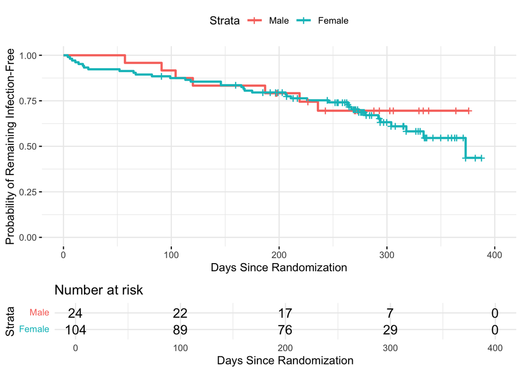

Figure 2: Kaplan-Meier Curves by Patient Sex

```r
# Create KM estimates stratified by sex
mfit.sex <- survfit(Surv(tstop, status) ~ sex, data=cgd)

# Generate plot
ggsurvplot(mfit.sex, data=cgd,
           ggtheme = theme_minimal(),
           legend.labs = c("Male","Female"),
           risk.table = TRUE,
           xlab = "Days Since Randomization",
           ylab = "Probability of Remaining Infection-Free")
```

**Statistical Interpretation**

The curves overlap substantially throughout follow-up. There is no consistent visual separation between males and females, consistent with the non-significant p-value of 0.606.

**Clinical Context**

# 6 Question 4: Age Effect

**Clinical Question:** Is there an association between patient age and infection risk?

When age is a **continuous** predictor, the hazard ratio represents the change in risk per 1-unit (1-year) increase.

```r
# Fit Cox model with age as continuous predictor
mfit.age <- coxph(Surv(tstop, status) ~ age, data=cgd)
summary(mfit.age)
```

```
Call:
coxph(formula = Surv(tstop, status) ~ age, data = cgd)

  n= 128, number of events= 44

        coef exp(coef) se(coef)      z Pr(>|z|)
age -0.02121   0.97901  0.01682 -1.261    0.207

    exp(coef) exp(-coef) lower .95 upper .95
age     0.979      1.021    0.9473     1.012

Concordance= 0.57  (se = 0.048 )
Likelihood ratio test= 1.69  on 1 df,   p=0.2
Wald test            = 1.59  on 1 df,   p=0.2
Score (logrank) test = 1.6  on 1 df,   p=0.2
```

**Statistical Interpretation**

- **Coefficient:** -0.02121 (negative = protective direction)
- **Hazard Ratio (per 1-year):** 0.979 [95% CI: 0.947, 1.012]
- **P-value:** 0.207 (NOT statistically significant)

**Clinical Interpretation**

For each **1-year increase** in age, the hazard of infection decreases by approximately **2.1%**. This suggests a trend toward lower risk in older patients.

**However:** This effect is not statistically significant (p = 0.207). The confidence interval [0.947, 1.012] crosses 1.0, so we cannot rule out no effect.

**Possible biological rationale:** Immune systems may mature with age, providing better defense even in CGD patients. Alternatively, this may reflect survivor bias (more severe cases may not survive to older ages).

# 7 Question 5: Clinically Meaningful Age Effect

**Clinical Question:** What is the hazard ratio for a **5-year** increase in age?

A 1-year change is often too small to be clinically meaningful. We can calculate the hazard ratio for larger, more relevant intervals.

**Mathematical Principle**

For continuous predictors:

$$HR_{5-year} = e^{5 \times \beta}$$

If the HR for a 1-year change is $e^\beta$, then for a 5-year change it becomes $(e^\beta)^5 = e^{5\beta}$.

```r
# Calculate 5-year hazard ratio
# Coefficient for age = -0.02121
exp(5 * -0.02121)
```

```
[1] 0.8993797
```

```r
# Calculate 95% Confidence Interval for 5-year change
exp(5 * confint(mfit.age))
```

```
        2.5 % 97.5 %
age 0.7627288 1.0605
```

**Statistical Interpretation**

- **5-Year Hazard Ratio:** 0.90 [95% CI: 0.76, 1.06]
- **Interpretation:** 10% reduction in risk per 5-year increase in age
- **Statistical significance:** Still non-significant (CI crosses 1.0)

**Clinical Interpretation**

A 5-year increase in age is associated with a **10% reduction** in infection risk (HR = 0.90). For example, a 15-year-old would have approximately 10% lower risk than a 10-year-old.

**Caveats:**

- The 95% CI [0.76, 1.06] still crosses 1.0
- We cannot conclude that age is a statistically significant predictor
- The direction is clinically intuitive (older children may have more mature immune function)
- Age should NOT be used as the sole factor for treatment decisions

# 8 Summary and Key Concepts

## 8.1 Hazard Ratio Reference Guide

Interpreting Hazard Ratios

| HR Value | Interpretation |
| --- | --- |
| HR = 1.0 | No effect (reference) |
| HR > 1.0 | Increased risk (harmful exposure) |
| HR < 1.0 | Decreased risk (protective exposure) |
| HR = 2.0 | 2x the risk (100% increased risk) |
| HR = 0.5 | 0.5x the risk (50% decreased risk) |

**Key Findings from This Analysis**

1. **Treatment Effect (Q1):** Placebo patients had **3x the infection risk** vs. gamma interferon (HR = 2.99, p = 0.001). This is both statistically significant AND clinically meaningful.
2. **Sex Effect (Q2-Q3):** No significant association between sex and infection risk (HR = 1.24, p = 0.606).
3. **Age Effect (Q4-Q5):** A trend toward lower risk in older patients (10% reduction per 5 years), but not statistically significant (p = 0.207).

**Key Teaching Points**

- **Cox regression** provides hazard ratios adjusted for time-to-event data and censoring.
- **Hazard Ratio > 1** means increased risk; **HR < 1** means decreased risk.
- **Continuous predictors:** The HR represents the change per 1-unit increase; multiply the coefficient for larger intervals.
- **Statistical significance** (p < 0.05) is not the same as **clinical importance**—always consider effect size.
- **Kaplan-Meier plots** visualize what Cox regression quantifies.

# 9 Practice Exercises

1. **Interpretation Practice:** If a Cox model for a new drug gives HR = 0.65 [95% CI: 0.45, 0.95] compared to standard treatment, what would you tell a patient about the drug’s benefit?
2. **Continuous Predictor:** If a model estimates the HR for BMI as 1.03 per unit, what is the HR for a 10-unit increase in BMI? Is this clinically concerning?
3. **Critical Appraisal:** In the sex analysis, the p-value was 0.606. Does this mean there is definitively no sex difference? What would you need to increase confidence in this conclusion?

*This tutorial was developed for CRP 245 at Duke University.*